# Zotero group SUA

Published

20 November 2026

Zotero data of 20 November 2026 · IPBES Literature Report 0.7.0 · [source code on GitHub](https://github.com/IPBES-Data/IPBES.LiteratureReport)

This report shows the state of the Zotero group **SUA** ([open the group in Zotero](https://www.zotero.org/groups/2344805)). It gives an overview of the literature in the group, and lists the items which should be corrected.

Each item in the lists can be opened in the Zotero **web** library or in the Zotero **app** on your computer, so that it can be corrected directly. Corrected items disappear from the lists the next time the report is updated. Some checks compare the items with [OpenAlex](https://openalex.org), an open catalogue of scholarly publications.

## Summary

[output not shown]

**Please fix**: these items contain errors. **Please check**: these items may need a correction. **For information**: no action needed unless the group uses this, e.g. tags.

## Items to fix

The lists are sorted by importance. Use the search field above a list to find an item. **web** opens the item in the Zotero web library, **app** in the Zotero app.

### Retracted publications

These publications have been retracted. Check whether they should still be cited, and mark or remove them in Zotero.

**✔ Nothing to fix.**

### DOI points to a different publication

The DOI of these items leads to a publication with a different title or year. Usually the DOI is wrong: open the DOI to see where it leads, and correct it in Zotero. If the titles match and only the year differs, the DOI is probably right and the date in Zotero wrong (unless it is a reprint or another edition): correct the date instead. Differences of one year (e.g. published online before print) are not listed.

If the DOI is right although title or year differ (e.g. a book chapter with the DOI of the whole book, or a wrong year in OpenAlex), add the line `DOI checked: correct` to Extra: the item is then no longer listed (the Zotero plugin offers this as “Keep as it is”).

Not listed here: items whose titles differ only by a subtitle missing on one side (OpenAlex often has the title without the part after the colon). They are most likely right; the Zotero plugin lists them separately.

| Open in Zotero | Title in Zotero | Year in Zotero | The DOI leads to | Its year | DOI |
| --- | --- | --- | --- | --- | --- |
| <a href="https://www.zotero.org/groups/2344805/items/586GMWNW" target="_blank">web</a> &middot; <a href="zotero://select/groups/2344805/items/586GMWNW">app</a> | Towards Measuring the Economic Value of Wildlife Watching Tourism in Africa | 2015 | Towards Measuring the Economic Value of Wildlife Watching Tourism in Africa – Briefing Paper | 2018 | <a href="https://doi.org/10.18111/9789284416752" target="_blank">10.18111/9789284416752</a> |
| <a href="https://www.zotero.org/groups/2344805/items/V2YAVGY3" target="_blank">web</a> &middot; <a href="zotero://select/groups/2344805/items/V2YAVGY3">app</a> | Towards measuring the economic value of wildlife watching tourism in Africa - briefing paper | 2014 | Towards Measuring the Economic Value of Wildlife Watching Tourism in Africa – Briefing Paper | 2018 | <a href="https://doi.org/10.18111/9789284416752" target="_blank">10.18111/9789284416752</a> |
| <a href="https://www.zotero.org/groups/2344805/items/VWGWZ6R6" target="_blank">web</a> &middot; <a href="zotero://select/groups/2344805/items/VWGWZ6R6">app</a> | Traces on the Rhodian shore | 1976 | Traces on the Rhodian Shore: Nature and Culture in Western Thought from Ancient Times to the End of the Eighteenth Century | 1967 | <a href="https://doi.org/10.1525/9780520343054" target="_blank">10.1525/9780520343054</a> |
| <a href="https://www.zotero.org/groups/2344805/items/BPGVBHXX" target="_blank">web</a> &middot; <a href="zotero://select/groups/2344805/items/BPGVBHXX">app</a> | Wildlife in the Anthropocene: Conservation after Nature | 2015 | Wildlife in the Anthropocene: Conservation after Nature | 2010 | <a href="https://doi.org/10.5749/9781452944289" target="_blank">10.5749/9781452944289</a> |
| <a href="https://www.zotero.org/groups/2344805/items/3HFQSL4Z" target="_blank">web</a> &middot; <a href="zotero://select/groups/2344805/items/3HFQSL4Z">app</a> | The stick: regulation as a tool of government. | 1998 | The Stick: Regulation as a Tool of Government | 2017 | <a href="https://doi.org/10.4324/9781315081748-3" target="_blank">10.4324/9781315081748-3</a> |
| <a href="https://www.zotero.org/groups/2344805/items/YUL2WEKK" target="_blank">web</a> &middot; <a href="zotero://select/groups/2344805/items/YUL2WEKK">app</a> | The State of Consumption Today | 2004 | The State of Consumption Today | 2015 | <a href="https://doi.org/10.2307/jj.41003643.8" target="_blank">10.2307/jj.41003643.8</a> |
| <a href="https://www.zotero.org/groups/2344805/items/UDNQUK5I" target="_blank">web</a> &middot; <a href="zotero://select/groups/2344805/items/UDNQUK5I">app</a> | The Rise of the Network Society | 2011 | The Rise of the Network Society | 2009 | <a href="https://doi.org/10.1002/9781444319514" target="_blank">10.1002/9781444319514</a> |
| <a href="https://www.zotero.org/groups/2344805/items/QNBD33V7" target="_blank">web</a> &middot; <a href="zotero://select/groups/2344805/items/QNBD33V7">app</a> | The intersection of food security and biodiversity conservation: a review | 2017 | The intersection of food security and biodiversity conservation: a review | 2015 | <a href="https://doi.org/10.1007/s10113-015-0873-3" target="_blank">10.1007/s10113-015-0873-3</a> |
| <a href="https://www.zotero.org/groups/2344805/items/MEA82SKS" target="_blank">web</a> &middot; <a href="zotero://select/groups/2344805/items/MEA82SKS">app</a> | Squaring the circle: reconciling fishing and conservation of aquatic ecosystems | 2015 | Squaring the circle: reconciling fishing and conservation of aquatic ecosystems | 2013 | <a href="https://doi.org/10.1111/faf.12056" target="_blank">10.1111/faf.12056</a> |
| <a href="https://www.zotero.org/groups/2344805/items/W9KLBL9W" target="_blank">web</a> &middot; <a href="zotero://select/groups/2344805/items/W9KLBL9W">app</a> | Social networks and the live reef food fish trade: examining sustainability | 2012 | Social Networks and the Live Reef Food Fish Trade: Examining Sustainability | 2019 | <a href="https://doi.org/10.14203/jissh.v4i0.119" target="_blank">10.14203/jissh.v4i0.119</a> |

[output cut: 38 more lines]

### Items which are in the group more than once

These items are in the group more than once, with the same DOI, or with the same title, year and first author. Keep one copy and merge or delete the others, e.g. with *Duplicate Items* in the Zotero app.

| Open in Zotero | Title | Copies |
| --- | --- | --- |
| <a href="https://www.zotero.org/groups/2344805/items/586GMWNW" target="_blank">web</a> &middot; <a href="zotero://select/groups/2344805/items/586GMWNW">app</a><br><a href="https://www.zotero.org/group… | Towards Measuring the Economic Value of Wildlife Watching Tourism in Africa | 2 |
| <a href="https://www.zotero.org/groups/2344805/items/7TN9Z64K" target="_blank">web</a> &middot; <a href="zotero://select/groups/2344805/items/7TN9Z64K">app</a><br><a href="https://www.zotero.org/group… | Vicuña conservation and poverty alleviation? Andean communities and international fibre markets | 2 |
| <a href="https://www.zotero.org/groups/2344805/items/PN2AEG95" target="_blank">web</a> &middot; <a href="zotero://select/groups/2344805/items/PN2AEG95">app</a><br><a href="https://www.zotero.org/group… | Sustaining conservation values in selectively logged tropical forests: the attained and the attainable | 2 |
| <a href="https://www.zotero.org/groups/2344805/items/3FVWTISB" target="_blank">web</a> &middot; <a href="zotero://select/groups/2344805/items/3FVWTISB">app</a><br><a href="https://www.zotero.org/group… | Fiji: commerce, carving and customary tenure | 2 |
| <a href="https://www.zotero.org/groups/2344805/items/Z9L4ZZEF" target="_blank">web</a> &middot; <a href="zotero://select/groups/2344805/items/Z9L4ZZEF">app</a><br><a href="https://www.zotero.org/group… | Cultural Keystone Species: Implications for Ecological Conservation and Restoration | 2 |
| <a href="https://www.zotero.org/groups/2344805/items/FFAUPYMJ" target="_blank">web</a> &middot; <a href="zotero://select/groups/2344805/items/FFAUPYMJ">app</a><br><a href="https://www.zotero.org/group… | Case study B: policies for Gnetum spp. trade in Cameroon: overcoming constraints that reduce benefits and discourage sustainability. | 2 |
| <a href="https://www.zotero.org/groups/2344805/items/NB4S8RF9" target="_blank">web</a> &middot; <a href="zotero://select/groups/2344805/items/NB4S8RF9">app</a><br><a href="https://www.zotero.org/group… | Can Non-Timber Forest Products Match Tropical Forest Conservation and Development Objectives? | 3 |
| <a href="https://www.zotero.org/groups/2344805/items/JWIU3NJW" target="_blank">web</a> &middot; <a href="zotero://select/groups/2344805/items/JWIU3NJW">app</a><br><a href="https://www.zotero.org/group… | Aquarium fish exploitation in western Amazonia: conservation issues in Peru | 2 |
| <a href="https://www.zotero.org/groups/2344805/items/ZFMSFZLB" target="_blank">web</a> &middot; <a href="zotero://select/groups/2344805/items/ZFMSFZLB">app</a><br><a href="https://www.zotero.org/group… | A tale of two villages: assessing the dynamics of fuelwood supply in communal landscapes in South Africa | 2 |
| <a href="https://www.zotero.org/groups/2344805/items/VMPD3QQD" target="_blank">web</a> &middot; <a href="zotero://select/groups/2344805/items/VMPD3QQD">app</a><br><a href="https://www.zotero.org/group… | The socio-economics of artisanal mining and bushmeat hunting around protected areas: Kahuzi–Biega National Park and Itombwe Nature Reserve, eastern Democratic Republic of Congo | 2 |

[output cut: 122 more lines]

### DOI field with an invalid DOI

The DOI field of these items contains something which is not a valid DOI. Correct or remove it.

| Open in Zotero | Title | Content of the DOI field |
| --- | --- | --- |
| <a href="https://www.zotero.org/groups/2344805/items/EDS42KVR" target="_blank">web</a> &middot; <a href="zotero://select/groups/2344805/items/EDS42KVR">app</a> | Traditional Uses of Medicinal Plants Used by Indigenous Communities for Veterinary Practices at Bajaur Agency, Pakistan | http://www.ncbi.nlm.nih.gov/pubmed/29378636 |
| <a href="https://www.zotero.org/groups/2344805/items/ZPYARER7" target="_blank">web</a> &middot; <a href="zotero://select/groups/2344805/items/ZPYARER7">app</a> | An Assessment of Small Unmanned Aerial Vehicles for Wildlife Research | 10/d82kg9 |
| <a href="https://www.zotero.org/groups/2344805/items/PRG9P5E9" target="_blank">web</a> &middot; <a href="zotero://select/groups/2344805/items/PRG9P5E9">app</a> | Microscope and spectacle: On the complexities of using new visual technologies to communicate about wildlife conservation | 10/gcbtzt |
| <a href="https://www.zotero.org/groups/2344805/items/AN67CHZP" target="_blank">web</a> &middot; <a href="zotero://select/groups/2344805/items/AN67CHZP">app</a> | Using Two-Eyed Seeing in Research With Indigenous People: An Integrative Review | DOI: |
| <a href="https://www.zotero.org/groups/2344805/items/LE4WLANH" target="_blank">web</a> &middot; <a href="zotero://select/groups/2344805/items/LE4WLANH">app</a> | The Impact of ICT Penetration on Deforestation: A Panel Data Evidence | 10/ggs75s |
| <a href="https://www.zotero.org/groups/2344805/items/UKQ4AXE2" target="_blank">web</a> &middot; <a href="zotero://select/groups/2344805/items/UKQ4AXE2">app</a> | The Human Relation With Nature and Technological Nature | 10/dn9dsb |
| <a href="https://www.zotero.org/groups/2344805/items/GCM6RQBP" target="_blank">web</a> &middot; <a href="zotero://select/groups/2344805/items/GCM6RQBP">app</a> | Transparency Under Scrutiny: Information Disclosure in Global Environmental Governance | 10/chx833 |
| <a href="https://www.zotero.org/groups/2344805/items/ACK7XTS3" target="_blank">web</a> &middot; <a href="zotero://select/groups/2344805/items/ACK7XTS3">app</a> | Are unmanned aircraft systems (UAS) the future of wildlife monitoring? A review of accomplishments and challenges | 10/gfc79h |
| <a href="https://www.zotero.org/groups/2344805/items/B23CMLVL" target="_blank">web</a> &middot; <a href="zotero://select/groups/2344805/items/B23CMLVL">app</a> | Uncertainty, Resource Exploitation, and Conservation: Lessons from History | http://www.jstor.org/stable/1942074 |
| <a href="https://www.zotero.org/groups/2344805/items/XPTTGU7X" target="_blank">web</a> &middot; <a href="zotero://select/groups/2344805/items/XPTTGU7X">app</a> | Conservation of the Ethiopian Church Forests: Threats, Opportunities and Implications for Their Management | https://linkinghub.elsevier.com/retrieve/pii/S0048969716302467 |

[output cut: 11 more lines]

### DOI which does not exist

The DOI of these items does not exist at doi.org: usually a typo, a shortened DOI, or a DOI with extra characters at the end. Where the DOI without these characters exists, it is given as suggestion. Otherwise find the right DOI, or remove it (then the search by title in OpenAlex can offer one).

| Open in Zotero | Title | Content of the DOI field | Suggestion |
| --- | --- | --- | --- |
| <a href="https://www.zotero.org/groups/2344805/items/T36PUCSZ" target="_blank">web</a> &middot; <a href="zotero://select/groups/2344805/items/T36PUCSZ">app</a> | Lifestyle entrepreneurs as agents of degrowth. The case of nature-based tourism businesses in Scandinavia | 10.4324/9780429320590-4/lifestyle-entrepreneurs-agents-degrowth-lusine-margaryan-peter-fredman-stian-stensland |  |
| <a href="https://www.zotero.org/groups/2344805/items/LYX5IXNY" target="_blank">web</a> &middot; <a href="zotero://select/groups/2344805/items/LYX5IXNY">app</a> | The State of World Fisheries and Aquaculture 2020: Sustainability in action | 10.4060/ca9229enalso |  |
| <a href="https://www.zotero.org/groups/2344805/items/7UJMNYQV" target="_blank">web</a> &middot; <a href="zotero://select/groups/2344805/items/7UJMNYQV">app</a> | Nesting, subsidiarity, and community-based environmental governance beyond the local level | 10.18352/ijc.50/ |  |
| <a href="https://www.zotero.org/groups/2344805/items/65VMMKJU" target="_blank">web</a> &middot; <a href="zotero://select/groups/2344805/items/65VMMKJU">app</a> | THE SOCIOECONOMIC CONDITIONS DETERMINING THE DEVELOPMENT, PERSISTENCE, AND DECLINE OF FOREST GARDEN SYSTEMS | 10.1663/0013-0001(2005)059[0245:tscdtd]2.0.co;2.pdf |  |

### DOI field with a link or prefix instead of the DOI

The DOI field of these items contains the DOI as a link (`https://doi.org/…`) or with a prefix (`DOI …`). Citation styles add the link themselves, so it would appear twice. Replace it with the DOI only.

**✔ Nothing to fix.**

### ISSN not in the standard form

The ISSN field of these items is not in the standard form `1234-567X` (several separated by “,”), or contains something which is not a valid ISSN, e.g. an ISBN.

| Open in Zotero | Title | Content of the ISSN field | Standard form | Not a valid ISSN |
| --- | --- | --- | --- | --- |
| <a href="https://www.zotero.org/groups/2344805/items/67BFPHVP" target="_blank">web</a> &middot; <a href="zotero://select/groups/2344805/items/67BFPHVP">app</a> | Global Migration and Population Health | 3030450082 | NA | 3030450082 |
| <a href="https://www.zotero.org/groups/2344805/items/V84RC4RP" target="_blank">web</a> &middot; <a href="zotero://select/groups/2344805/items/V84RC4RP">app</a> | Ghosts of the mountains: the role of wildlife conservation in sustainable tourism–a case study of snow leopard conservation and sustainable tourism in Mongolia | 178466085X | NA | 178466085X |
| <a href="https://www.zotero.org/groups/2344805/items/3YQZTM5Q" target="_blank">web</a> &middot; <a href="zotero://select/groups/2344805/items/3YQZTM5Q">app</a> | Bonn Guidelines on Access to Genetic Resources and Fair and Equitable Sharing of the Benefits Arising out of their Utilization | 9280722557 | NA | 9280722557 |
| <a href="https://www.zotero.org/groups/2344805/items/LRL53YS4" target="_blank">web</a> &middot; <a href="zotero://select/groups/2344805/items/LRL53YS4">app</a> | World Dispersals and Genetic Diversity of Mankind: The Out-of-Africa Theory and Its Challenges | 9780124201903 | NA | 9780124201903 |
| <a href="https://www.zotero.org/groups/2344805/items/TJT6IJ2A" target="_blank">web</a> &middot; <a href="zotero://select/groups/2344805/items/TJT6IJ2A">app</a> | Specimen collection: an essential tool | 1095-9203 (Electronic) 0036-8075 (Linking) | NA | (Electronic), (Linking) |
| <a href="https://www.zotero.org/groups/2344805/items/AI6UNAFH" target="_blank">web</a> &middot; <a href="zotero://select/groups/2344805/items/AI6UNAFH">app</a> | Biological sustainability of live shearing of vicuna in Peru | 0888-8892 (Print) 0888-8892 (Linking) | NA | (Print), (Linking) |
| <a href="https://www.zotero.org/groups/2344805/items/9JA3LWTU" target="_blank">web</a> &middot; <a href="zotero://select/groups/2344805/items/9JA3LWTU">app</a> | Entre délinquance et résistance au Congo belge: l'interprétation coloniale du braconnage | 978-2-86432-582-6 | NA | 978-2-86432-582-6 |
| <a href="https://www.zotero.org/groups/2344805/items/ZYCEASNZ" target="_blank">web</a> &middot; <a href="zotero://select/groups/2344805/items/ZYCEASNZ">app</a> | Value and impacts of collecting vertebrate voucher specimens, with guidelines for ethical collection | ISSN 1447–2554 (online) | NA | ISSN, 1447–2554, (online) |
| <a href="https://www.zotero.org/groups/2344805/items/6R7M2ZAZ" target="_blank">web</a> &middot; <a href="zotero://select/groups/2344805/items/6R7M2ZAZ">app</a> | Eradications of Invasive Alien Species in Europe: A Review | 1-4020-2902-0 | NA | 1-4020-2902-0 |
| <a href="https://www.zotero.org/groups/2344805/items/AZU6JMB6" target="_blank">web</a> &middot; <a href="zotero://select/groups/2344805/items/AZU6JMB6">app</a> | Équilibre paradoxal: sédentarité et sacralité chez les nomades marins moken | 0336-1519 - online 1760-737X | NA | -, online |

[output cut: 9 more lines]

### DOI in the wrong field

These items have no DOI in the DOI field, but a DOI in the URL or Extra field. Copy the DOI into the DOI field.

| Open in Zotero | Title | DOI in URL | DOI in Extra |
| --- | --- | --- | --- |
| <a href="https://www.zotero.org/groups/2344805/items/2FE59TUU" target="_blank">web</a> &middot; <a href="zotero://select/groups/2344805/items/2FE59TUU">app</a> | The Black Seas fisheries and ecosystem change: discriminating between natural variability and human-related effects | <a href="https://doi.org/10.1111/j.1365-2427.2008.02115.x" target="_blank">10.1111/j.1365-2427.2008.02115.x</a> |  |
| <a href="https://www.zotero.org/groups/2344805/items/6FT95VBM" target="_blank">web</a> &middot; <a href="zotero://select/groups/2344805/items/6FT95VBM">app</a> | Conservation hunting concepts, Canada’s Inuit, and polar bear hunting | <a href="https://doi.org/10.4324/9780203934326-19" target="_blank">10.4324/9780203934326-19</a> |  |
| <a href="https://www.zotero.org/groups/2344805/items/E3EPYLEA" target="_blank">web</a> &middot; <a href="zotero://select/groups/2344805/items/E3EPYLEA">app</a> | Globalization and land use transitions in Latin America | <a href="https://doi.org/10.1057/9780230603554.crossrefgoogle" target="_blank">10.1057/9780230603554.crossrefgoogle</a> |  |

### DOI not found in OpenAlex

These DOIs exist, but were not found in OpenAlex (DOIs which do not exist are listed above). If the DOI leads to the right publication, the publication is simply not (yet) in OpenAlex and nothing needs to be done.

| Open in Zotero | Title | DOI |
| --- | --- | --- |
| <a href="https://www.zotero.org/groups/2344805/items/I39S3BJN" target="_blank">web</a> &middot; <a href="zotero://select/groups/2344805/items/I39S3BJN">app</a> | Economic impacts | <a href="https://doi.org/10.1079/9780851993683.0363" target="_blank">10.1079/9780851993683.0363</a> |
| <a href="https://www.zotero.org/groups/2344805/items/SYXCJUJY" target="_blank">web</a> &middot; <a href="zotero://select/groups/2344805/items/SYXCJUJY">app</a> | Berries and Related Fruits | <a href="https://doi.org/10.1016/b978-0-12-384947-2.00060-x" target="_blank">10.1016/b978-0-12-384947-2.00060-x</a> |
| <a href="https://www.zotero.org/groups/2344805/items/LG2FLMPI" target="_blank">web</a> &middot; <a href="zotero://select/groups/2344805/items/LG2FLMPI">app</a> | Domestication of Plants | <a href="https://doi.org/10.1016/b978-0-444-52512-3.00231-x" target="_blank">10.1016/b978-0-444-52512-3.00231-x</a> |
| <a href="https://www.zotero.org/groups/2344805/items/URIN2GP9" target="_blank">web</a> &middot; <a href="zotero://select/groups/2344805/items/URIN2GP9">app</a> | The IPBES regional assessment report on Biodiversity and Ecosystem Services for the Americas | <a href="https://doi.org/10.5281/zenodo.3236252" target="_blank">10.5281/zenodo.3236252</a> |
| <a href="https://www.zotero.org/groups/2344805/items/U7335URT" target="_blank">web</a> &middot; <a href="zotero://select/groups/2344805/items/U7335URT">app</a> | Final report of the expert group on quality of life indicators: 2017 edition. | <a href="https://doi.org/10.2785/021270" target="_blank">10.2785/021270</a> |
| <a href="https://www.zotero.org/groups/2344805/items/YTRVCLR9" target="_blank">web</a> &middot; <a href="zotero://select/groups/2344805/items/YTRVCLR9">app</a> | Ecosystem Effects of Acidic Deposition | <a href="https://doi.org/10.1002/9781119300762.wsts0043" target="_blank">10.1002/9781119300762.wsts0043</a> |
| <a href="https://www.zotero.org/groups/2344805/items/GWN68BXX" target="_blank">web</a> &middot; <a href="zotero://select/groups/2344805/items/GWN68BXX">app</a> | Summary for policymakers of the regional assessment report on biodiversity and ecosystem services for Asia and the Pacific of the Intergovernmental Science-Policy Platform on Biodiversity and Ecosyste… | <a href="https://doi.org/10.5281/zenodo.3237373" target="_blank">10.5281/zenodo.3237373</a> |
| <a href="https://www.zotero.org/groups/2344805/items/ID6RJXUX" target="_blank">web</a> &middot; <a href="zotero://select/groups/2344805/items/ID6RJXUX">app</a> | Annex I: Glossary of the Global assessment report on biodiversity and ecosystem services of the Intergovernmental Science-Policy Platform on Biodiversity and Ecosystem Services. | <a href="https://doi.org/10.5281/zenodo.5020598" target="_blank">10.5281/zenodo.5020598</a> |
| <a href="https://www.zotero.org/groups/2344805/items/KXQGTCY8" target="_blank">web</a> &middot; <a href="zotero://select/groups/2344805/items/KXQGTCY8">app</a> | The IPBES assessment report on Land Degradation and Restoration | <a href="https://doi.org/10.5281/zenodo.3237392" target="_blank">10.5281/zenodo.3237392</a> |
| <a href="https://www.zotero.org/groups/2344805/items/HY7NC7ZH" target="_blank">web</a> &middot; <a href="zotero://select/groups/2344805/items/HY7NC7ZH">app</a> | Summary for policymakers of the regional assessment report on biodiversity and ecosystem services for the Americas of the Intergovernmental Science-Policy Platform on Biodiversity and Ecosystem Servic… | <a href="https://doi.org/10.5281/zenodo.3236252" target="_blank">10.5281/zenodo.3236252</a> |

[output cut: 14 more lines]

### Missing or unusual publication year

These items have no date, a date from which no year could be read, or a year in the future. Correct the date in Zotero.

| Open in Zotero | Title | Date | Problem | Date in OpenAlex |
| --- | --- | --- | --- | --- |
| <a href="https://www.zotero.org/groups/2344805/items/NLDWRYZP" target="_blank">web</a> &middot; <a href="zotero://select/groups/2344805/items/NLDWRYZP">app</a> | What is Good Governance? |  | No date | NA |
| <a href="https://www.zotero.org/groups/2344805/items/NK28G9IV" target="_blank">web</a> &middot; <a href="zotero://select/groups/2344805/items/NK28G9IV">app</a> | Agriculture modifies the seasonal decline of breeding success in a tropical wild bird population |  | No date | 2014-06-27 |
| <a href="https://www.zotero.org/groups/2344805/items/YF4AZ2LV" target="_blank">web</a> &middot; <a href="zotero://select/groups/2344805/items/YF4AZ2LV">app</a> | Eke Eijgelaar & Stefan Gössling Desirable tourism transport futures 2018 |  | No date | NA |
| <a href="https://www.zotero.org/groups/2344805/items/AE2E4CRA" target="_blank">web</a> &middot; <a href="zotero://select/groups/2344805/items/AE2E4CRA">app</a> | Effects of habitat fragmentation on biodiversity |  | No date | 2003-11-01 |
| <a href="https://www.zotero.org/groups/2344805/items/AXJ9WPXQ" target="_blank">web</a> &middot; <a href="zotero://select/groups/2344805/items/AXJ9WPXQ">app</a> | State of the World's Plants and Fungi KEW |  | No date | NA |
| <a href="https://www.zotero.org/groups/2344805/items/SXL7BRCE" target="_blank">web</a> &middot; <a href="zotero://select/groups/2344805/items/SXL7BRCE">app</a> | Desde la Tierra de los Osos (Ozolotepec) // From the Land of bears (Ozolotepec) |  | No date | NA |
| <a href="https://www.zotero.org/groups/2344805/items/DYKY9ZEX" target="_blank">web</a> &middot; <a href="zotero://select/groups/2344805/items/DYKY9ZEX">app</a> | & Tongo, I.(2008). Distribution of Lindane in water, sediment, and fsh from the Warri River of the Niger Delta, Nigeria |  | No date | NA |
| <a href="https://www.zotero.org/groups/2344805/items/F95GBVB7" target="_blank">web</a> &middot; <a href="zotero://select/groups/2344805/items/F95GBVB7">app</a> | M(2007).Biochemical parameters of plants as indicators of air pollution |  | No date | NA |
| <a href="https://www.zotero.org/groups/2344805/items/3MCLEEWJ" target="_blank">web</a> &middot; <a href="zotero://select/groups/2344805/items/3MCLEEWJ">app</a> | Technological innovation in agricultural co-operatives in China: implications for agro-food innovation policies |  | No date | NA |
| <a href="https://www.zotero.org/groups/2344805/items/YQMBKI27" target="_blank">web</a> &middot; <a href="zotero://select/groups/2344805/items/YQMBKI27">app</a> | Caso: Aprovechamiento de los huevos de tortuga Lora: Refugio Nacional de Vida Silvestre Ostional |  | No date | NA |

[output cut: 11 more lines]

### Empty journal, volume, issue or pages, found in OpenAlex

These journal articles have an empty journal, volume, issue or pages field, and OpenAlex has the value for their DOI. Check it with the DOI and fill in the field.

| Open in Zotero | Title | Field | Value in OpenAlex | DOI |
| --- | --- | --- | --- | --- |
| <a href="https://www.zotero.org/groups/2344805/items/MNFI3Y7K" target="_blank">web</a> &middot; <a href="zotero://select/groups/2344805/items/MNFI3Y7K">app</a> | ).Effects of industrial air pollution on wildlife | Issue | 3 | <a href="https://doi.org/10.1016/0006-3207(79)90039-9" target="_blank">10.1016/0006-3207(79)90039-9</a> |
| <a href="https://www.zotero.org/groups/2344805/items/5PHWAVAL" target="_blank">web</a> &middot; <a href="zotero://select/groups/2344805/items/5PHWAVAL">app</a> | 20 years of Nordic nature-based tourism research: a review and future research agenda | Volume | 21 | <a href="https://doi.org/10.1080/15022250.2020.1823247" target="_blank">10.1080/15022250.2020.1823247</a> |
| <a href="https://www.zotero.org/groups/2344805/items/5PHWAVAL" target="_blank">web</a> &middot; <a href="zotero://select/groups/2344805/items/5PHWAVAL">app</a> | 20 years of Nordic nature-based tourism research: a review and future research agenda | Issue | 1 | <a href="https://doi.org/10.1080/15022250.2020.1823247" target="_blank">10.1080/15022250.2020.1823247</a> |
| <a href="https://www.zotero.org/groups/2344805/items/QBSR9C9Z" target="_blank">web</a> &middot; <a href="zotero://select/groups/2344805/items/QBSR9C9Z">app</a> | A case study on trade in threatened Tiger Geckos (Goniurosaurus) in Vietnam including updated information on the abundance of the Endangered G-catbaensis | Volume | 33 | <a href="https://doi.org/10.3897/natureconservation.32.33590" target="_blank">10.3897/natureconservation.32.33590</a> |
| <a href="https://www.zotero.org/groups/2344805/items/T34IN5ZK" target="_blank">web</a> &middot; <a href="zotero://select/groups/2344805/items/T34IN5ZK">app</a> | A Caça e o Caçador: uma Análise Crítica da Legislação Brasileira sobre o Uso da Fauna por Populações Indígenas e Tradicionais na Amazônia | Journal | Biodiversidade Brasileira | <a href="https://doi.org/10.37002/biodiversidadebrasileira.v8i2.779" target="_blank">10.37002/biodiversidadebrasileira.v8i2.779</a> |
| <a href="https://www.zotero.org/groups/2344805/items/T34IN5ZK" target="_blank">web</a> &middot; <a href="zotero://select/groups/2344805/items/T34IN5ZK">app</a> | A Caça e o Caçador: uma Análise Crítica da Legislação Brasileira sobre o Uso da Fauna por Populações Indígenas e Tradicionais na Amazônia | Volume | 8 | <a href="https://doi.org/10.37002/biodiversidadebrasileira.v8i2.779" target="_blank">10.37002/biodiversidadebrasileira.v8i2.779</a> |
| <a href="https://www.zotero.org/groups/2344805/items/T34IN5ZK" target="_blank">web</a> &middot; <a href="zotero://select/groups/2344805/items/T34IN5ZK">app</a> | A Caça e o Caçador: uma Análise Crítica da Legislação Brasileira sobre o Uso da Fauna por Populações Indígenas e Tradicionais na Amazônia | Issue | 2 | <a href="https://doi.org/10.37002/biodiversidadebrasileira.v8i2.779" target="_blank">10.37002/biodiversidadebrasileira.v8i2.779</a> |
| <a href="https://www.zotero.org/groups/2344805/items/T7LQXD3R" target="_blank">web</a> &middot; <a href="zotero://select/groups/2344805/items/T7LQXD3R">app</a> | A feasibility study to monitor the macroinvertebrate diversity of the River Nile using three sampling methods | Issue | 1 | <a href="https://doi.org/10.1007/s10750-005-1262-6" target="_blank">10.1007/s10750-005-1262-6</a> |
| <a href="https://www.zotero.org/groups/2344805/items/RBELUX5I" target="_blank">web</a> &middot; <a href="zotero://select/groups/2344805/items/RBELUX5I">app</a> | A field-based quantitative analysis of sublethal effects of air pollution on pollinators | Issue | 34 | <a href="https://doi.org/10.1073/pnas.2009074117" target="_blank">10.1073/pnas.2009074117</a> |
| <a href="https://www.zotero.org/groups/2344805/items/6Y7KY4UV" target="_blank">web</a> &middot; <a href="zotero://select/groups/2344805/items/6Y7KY4UV">app</a> | A framework for results-based management in fisheries | Issue | 2 | <a href="https://doi.org/10.1111/faf.12257" target="_blank">10.1111/faf.12257</a> |

[output cut: 326 more lines]

### Language not given as a language code

The language of these items is not given as a language code (`en`, `fr`, `en-US`), e.g. as `English` or `eng`. Citation styles only recognise the codes. Where the language was recognised, the code is shown; otherwise look up the code in the [ISO 639-1 list](https://en.wikipedia.org/wiki/List_of_ISO_639_language_codes).

| Open in Zotero | Title | Language | Language code |
| --- | --- | --- | --- |
| <a href="https://www.zotero.org/groups/2344805/items/7FKZMWYU" target="_blank">web</a> &middot; <a href="zotero://select/groups/2344805/items/7FKZMWYU">app</a> | Surface water availability: Implications for heterogeneity and ecosystem processes | English. | NA |
| <a href="https://www.zotero.org/groups/2344805/items/M9CVF4T3" target="_blank">web</a> &middot; <a href="zotero://select/groups/2344805/items/M9CVF4T3">app</a> | Governance for Justice and Environmental Sustainability. | English. | NA |
| <a href="https://www.zotero.org/groups/2344805/items/Y9X2NJLZ" target="_blank">web</a> &middot; <a href="zotero://select/groups/2344805/items/Y9X2NJLZ">app</a> | Governing public-private partnerships: analysing and managing the processes and institutional characteristics of public-private partnerships | English. | NA |
| <a href="https://www.zotero.org/groups/2344805/items/8MHGM2SF" target="_blank">web</a> &middot; <a href="zotero://select/groups/2344805/items/8MHGM2SF">app</a> | The Wild Orchid Trade in a Mexican Local Market: Diversity and Economics | Inglés estadounidense | NA |
| <a href="https://www.zotero.org/groups/2344805/items/LYX5IXNY" target="_blank">web</a> &middot; <a href="zotero://select/groups/2344805/items/LYX5IXNY">app</a> | The State of World Fisheries and Aquaculture 2020: Sustainability in action | other | NA |
| <a href="https://www.zotero.org/groups/2344805/items/NRKMS6VC" target="_blank">web</a> &middot; <a href="zotero://select/groups/2344805/items/NRKMS6VC">app</a> | Patrimoines naturels au sud: territoires, identités et stratégies locales : ouvrage issu du séminaire organisé conjointement par le Département "hommes, natures, sociétés" du Muséum national d'histoir… | French and English. | NA |
| <a href="https://www.zotero.org/groups/2344805/items/84Q5I3IQ" target="_blank">web</a> &middot; <a href="zotero://select/groups/2344805/items/84Q5I3IQ">app</a> | Estrategias de conservación en México para el borrego cimarrón (Ovis canadensis) y el berrendo (Antilocapra americana) | Español | NA |
| <a href="https://www.zotero.org/groups/2344805/items/ICG3WCDB" target="_blank">web</a> &middot; <a href="zotero://select/groups/2344805/items/ICG3WCDB">app</a> | Sistematización del aprovechamiento de huevos de la tortuga lora (Lepidochelys olivacea) en el Refugio Nacional de Vida Silvestre Ostional (1983-2015) | Español | NA |
| <a href="https://www.zotero.org/groups/2344805/items/YQMBKI27" target="_blank">web</a> &middot; <a href="zotero://select/groups/2344805/items/YQMBKI27">app</a> | Caso: Aprovechamiento de los huevos de tortuga Lora: Refugio Nacional de Vida Silvestre Ostional | Español | NA |
| <a href="https://www.zotero.org/groups/2344805/items/Y6N4STVW" target="_blank">web</a> &middot; <a href="zotero://select/groups/2344805/items/Y6N4STVW">app</a> | Norsk rødliste for arter 2010 = The 2010 Norwegian red list for species | Text engl. und norweg. | NA |

[output cut: 6 more lines]

### Language differs from OpenAlex

The language of these items differs from the language of their DOI in OpenAlex. OpenAlex detects the language from the title and abstract, and many publications in other languages have an English abstract: the language in Zotero is often right. Check the publication and correct the language if needed; if it is right, add the line `Language checked: correct` to Extra, and the item is no longer listed.

| Open in Zotero | Title | Language | Language in OpenAlex | DOI |
| --- | --- | --- | --- | --- |
| <a href="https://www.zotero.org/groups/2344805/items/WAI44RVM" target="_blank">web</a> &middot; <a href="zotero://select/groups/2344805/items/WAI44RVM">app</a> | Urban myths of organic farming | et | en | <a href="https://doi.org/10.1038/35068639" target="_blank">10.1038/35068639</a> |
| <a href="https://www.zotero.org/groups/2344805/items/R477DPRX" target="_blank">web</a> &middot; <a href="zotero://select/groups/2344805/items/R477DPRX">app</a> | Urbanisation, plant traits and the composition of urban floras | fr | en | <a href="https://doi.org/10.1016/j.ppees.2014.10.002" target="_blank">10.1016/j.ppees.2014.10.002</a> |
| <a href="https://www.zotero.org/groups/2344805/items/PNEFZCMJ" target="_blank">web</a> &middot; <a href="zotero://select/groups/2344805/items/PNEFZCMJ">app</a> | Wildlife tourism | et | en | <a href="https://doi.org/10.2307/jj.30945697" target="_blank">10.2307/jj.30945697</a> |
| <a href="https://www.zotero.org/groups/2344805/items/7TN9Z64K" target="_blank">web</a> &middot; <a href="zotero://select/groups/2344805/items/7TN9Z64K">app</a> | Vicuña conservation and poverty alleviation? Andean communities and international fibre markets | fr | en | <a href="https://doi.org/10.18352/bmgn-lchr.139" target="_blank">10.18352/bmgn-lchr.139</a> |
| <a href="https://www.zotero.org/groups/2344805/items/R7EXM7S8" target="_blank">web</a> &middot; <a href="zotero://select/groups/2344805/items/R7EXM7S8">app</a> | The practice of transition management: Examples and lessons from four distinct cases | fr | en | <a href="https://doi.org/10.1016/j.futures.2009.11.009" target="_blank">10.1016/j.futures.2009.11.009</a> |
| <a href="https://www.zotero.org/groups/2344805/items/REZDTMQ8" target="_blank">web</a> &middot; <a href="zotero://select/groups/2344805/items/REZDTMQ8">app</a> | The importance of human–macaque folklore for conservation in Lore Lindu National Park, Sulawesi, Indonesia | fr | en | <a href="https://doi.org/10.1017/s0030605309990925" target="_blank">10.1017/s0030605309990925</a> |
| <a href="https://www.zotero.org/groups/2344805/items/F2URC8GK" target="_blank">web</a> &middot; <a href="zotero://select/groups/2344805/items/F2URC8GK">app</a> | Sustainable harvesting of coco de mer, Lodoicea maldivica, in the Vallée de Mai, Seychelles | fr | en | <a href="https://doi.org/10.1016/j.foreco.2010.09.032" target="_blank">10.1016/j.foreco.2010.09.032</a> |
| <a href="https://www.zotero.org/groups/2344805/items/R5269G63" target="_blank">web</a> &middot; <a href="zotero://select/groups/2344805/items/R5269G63">app</a> | Guanaco management in Argentina: taking a commons perspective | en | es | <a href="https://doi.org/10.1353/lag.2013.0002" target="_blank">10.1353/lag.2013.0002</a> |
| <a href="https://www.zotero.org/groups/2344805/items/NSSDMYAN" target="_blank">web</a> &middot; <a href="zotero://select/groups/2344805/items/NSSDMYAN">app</a> | Global hotspots and correlates of emerging zoonotic diseases | fr | en | <a href="https://doi.org/10.1038/s41467-017-00923-8" target="_blank">10.1038/s41467-017-00923-8</a> |
| <a href="https://www.zotero.org/groups/2344805/items/A4G3RP78" target="_blank">web</a> &middot; <a href="zotero://select/groups/2344805/items/A4G3RP78">app</a> | Fire-and distance-dependent recruitment of the Brazil nut in the Peruvian Amazon | fr | en | <a href="https://doi.org/10.1016/j.foreco.2018.05.052" target="_blank">10.1016/j.foreco.2018.05.052</a> |

[output cut: 88 more lines]

### No language

These items have no language. Where possible, a language is proposed: from OpenAlex for items with a DOI, or else detected from the abstract (with the Compact Language Detector 2, a statistical method, not AI). Both are the language of the title or abstract, which may differ from the language of the publication.

| Open in Zotero | Title | Proposed language | From | DOI |
| --- | --- | --- | --- | --- |
| <a href="https://www.zotero.org/groups/2344805/items/EAHDJHX5" target="_blank">web</a> &middot; <a href="zotero://select/groups/2344805/items/EAHDJHX5">app</a> | UNITED NATIONS CONVENTION TO COMBAT DESERTIFICATION | NA | NA |  |
| <a href="https://www.zotero.org/groups/2344805/items/B36K6SBT" target="_blank">web</a> &middot; <a href="zotero://select/groups/2344805/items/B36K6SBT">app</a> | The winners: species that have benefited from 30 years of conservation action | en | OpenAlex | <a href="https://doi.org/10.1080/03036758.2018.1518249" target="_blank">10.1080/03036758.2018.1518249</a> |
| <a href="https://www.zotero.org/groups/2344805/items/XSHGUA7E" target="_blank">web</a> &middot; <a href="zotero://select/groups/2344805/items/XSHGUA7E">app</a> | The whaling versus whale-watching debate: The resumption of Icelandic whaling | en | OpenAlex | <a href="https://doi.org/10.1017/cbo9781139018166.009" target="_blank">10.1017/cbo9781139018166.009</a> |
| <a href="https://www.zotero.org/groups/2344805/items/5XJKKAFP" target="_blank">web</a> &middot; <a href="zotero://select/groups/2344805/items/5XJKKAFP">app</a> | The “Anthropocene” | NA | NA |  |
| <a href="https://www.zotero.org/groups/2344805/items/SPI2DDZS" target="_blank">web</a> &middot; <a href="zotero://select/groups/2344805/items/SPI2DDZS">app</a> | The ‘killer shrimp’Dikerogammarus villosus (Crustacea, Amphipoda) invading Alpine lakes: overland transport by recreational boats and scuba‐diving gear as potential entry vectors? | en | OpenAlex | <a href="https://doi.org/10.1002/aqc.2329" target="_blank">10.1002/aqc.2329</a> |
| <a href="https://www.zotero.org/groups/2344805/items/QKQELR74" target="_blank">web</a> &middot; <a href="zotero://select/groups/2344805/items/QKQELR74">app</a> | Trust and consumer risk perceptions regarding BSE and chronic wasting disease | en | OpenAlex | <a href="https://doi.org/10.1002/agr.21524" target="_blank">10.1002/agr.21524</a> |
| <a href="https://www.zotero.org/groups/2344805/items/37QLPLJ9" target="_blank">web</a> &middot; <a href="zotero://select/groups/2344805/items/37QLPLJ9">app</a> | Transboundary initiatives and snow leopard conservation | en | OpenAlex | <a href="https://doi.org/10.1016/b978-0-12-802213-9.00019-5" target="_blank">10.1016/b978-0-12-802213-9.00019-5</a> |
| <a href="https://www.zotero.org/groups/2344805/items/XUJRHZFC" target="_blank">web</a> &middot; <a href="zotero://select/groups/2344805/items/XUJRHZFC">app</a> | Trophy Hunting and Conservation in Africa: Problems and One Potential Solution | en | OpenAlex | <a href="https://doi.org/10.1111/j.1523-1739.2006.00594.x" target="_blank">10.1111/j.1523-1739.2006.00594.x</a> |
| <a href="https://www.zotero.org/groups/2344805/items/5IEE5L8L" target="_blank">web</a> &middot; <a href="zotero://select/groups/2344805/items/5IEE5L8L">app</a> | Transboundary river basin agreements in the Mekong and Zambezi basins: Enhancing environmental security or securitizing the environment? | en | OpenAlex | <a href="https://doi.org/10.1007/s10784-007-9036-4" target="_blank">10.1007/s10784-007-9036-4</a> |
| <a href="https://www.zotero.org/groups/2344805/items/JZX4WK4L" target="_blank">web</a> &middot; <a href="zotero://select/groups/2344805/items/JZX4WK4L">app</a> | Transboundary river cooperation and the regional public good: The case of the Mekong River | en | OpenAlex | <a href="https://doi.org/10.1355/cs31-2f" target="_blank">10.1355/cs31-2f</a> |

[output cut: 2550 more lines]

### Items without DOI, ISBN, ISSN or URL

Readers cannot easily find these items. Add a DOI, ISBN, ISSN or URL if one exists. Some items, e.g. personal communications, have none.

| Open in Zotero | Title | Type |
| --- | --- | --- |
| <a href="https://www.zotero.org/groups/2344805/items/PQL4KUY3" target="_blank">web</a> &middot; <a href="zotero://select/groups/2344805/items/PQL4KUY3">app</a> | The world of organic agriculture | book section |
| <a href="https://www.zotero.org/groups/2344805/items/GQ6UPCMJ" target="_blank">web</a> &middot; <a href="zotero://select/groups/2344805/items/GQ6UPCMJ">app</a> | The Year 2000: A Framework for Speculation on the Next Thirty-three Years | book |
| <a href="https://www.zotero.org/groups/2344805/items/YEV68XJC" target="_blank">web</a> &middot; <a href="zotero://select/groups/2344805/items/YEV68XJC">app</a> | Tourism and sustainability: Development. Globalisation and New Tourism in the Third World | book |
| <a href="https://www.zotero.org/groups/2344805/items/VMY4AECW" target="_blank">web</a> &middot; <a href="zotero://select/groups/2344805/items/VMY4AECW">app</a> | Tourism and climate change: Risks and opportunities | book |
| <a href="https://www.zotero.org/groups/2344805/items/QSV3KFQY" target="_blank">web</a> &middot; <a href="zotero://select/groups/2344805/items/QSV3KFQY">app</a> | Tourism and climate change: Impacts, adaptation and mitigation | book |
| <a href="https://www.zotero.org/groups/2344805/items/7QS2FWK9" target="_blank">web</a> &middot; <a href="zotero://select/groups/2344805/items/7QS2FWK9">app</a> | Tibetan medicinal plants | book |
| <a href="https://www.zotero.org/groups/2344805/items/72VIRSY9" target="_blank">web</a> &middot; <a href="zotero://select/groups/2344805/items/72VIRSY9">app</a> | Violent Environments | book |
| <a href="https://www.zotero.org/groups/2344805/items/NFA22LVF" target="_blank">web</a> &middot; <a href="zotero://select/groups/2344805/items/NFA22LVF">app</a> | Voices of the Poor: Can Anyone Hear Us? | book |
| <a href="https://www.zotero.org/groups/2344805/items/XZ4C9G34" target="_blank">web</a> &middot; <a href="zotero://select/groups/2344805/items/XZ4C9G34">app</a> | The Tipping Point: How Little Things Can Make a Big Difference | book |
| <a href="https://www.zotero.org/groups/2344805/items/VV3VZAGJ" target="_blank">web</a> &middot; <a href="zotero://select/groups/2344805/items/VV3VZAGJ">app</a> | The Thunder Tree: Lessons from an urban wildland | book |

[output cut: 898 more lines]

### Items without DOI, for which a DOI was found

OpenAlex was searched by title for items without a DOI (journal articles, books, book sections, reports, conference papers, theses, preprints), and by the PubMed ID (line `PMID: …` in Extra); Crossref was searched by ISBN and title. The publications found by title are compared by title, year and first author: a *likely* match agrees in all three, a *possible* match has a similar title, but e.g. a different year or author. A publication found by PubMed ID is a likely match; if it has no DOI, its OpenAlex ID can be added to Extra instead. A publication found by ISBN is a likely match if the title is the same. For items with an ISBN or PubMed ID, publications found by title are only listed if they are likely matches. Open the DOI to check that it is the same publication, and add the DOI in Zotero.

If none of them is the item, add the line `No DOI: checked` to Extra: the item is then no longer listed (the Zotero plugin offers this as “Keep as it is”).

| Open in Zotero | Title | Year | Author | Found in OpenAlex | Year (OpenAlex) | Author (OpenAlex) | Found by | Match | DOI |
| --- | --- | --- | --- | --- | --- | --- | --- | --- | --- |
| <a href="https://www.zotero.org/groups/2344805/items/W7I2EVGI" target="_blank">web</a> &middot; <a href="zotero://select/groups/2344805/items/W7I2EVGI">app</a> | A 2018 horizon scan of emerging issues for global conservation and biological diversity | 2018 | Sutherland, William J | A 2018 Horizon Scan of Emerging Issues for Global Conservation and Biological Diversity | 2017 | William J. Sutherland | title | likely | <a href="https://doi.org/10.1016/j.tree.2017.11.006" target="_blank">10.1016/j.tree.2017.11.006</a> |
| <a href="https://www.zotero.org/groups/2344805/items/5NGX2QEN" target="_blank">web</a> &middot; <a href="zotero://select/groups/2344805/items/5NGX2QEN">app</a> | A Critique of Silviculture: Managing For Complexity | 2009 | Puettmann, Klaus | A critique of silviculture: managing for complexity | 2009 | NA | title | likely | <a href="https://doi.org/10.5860/choice.46-5609" target="_blank">10.5860/choice.46-5609</a> |
| <a href="https://www.zotero.org/groups/2344805/items/PEXC25RM" target="_blank">web</a> &middot; <a href="zotero://select/groups/2344805/items/PEXC25RM">app</a> | Carving out a future: forests, livelihoods and the international woodcarving trade | 2005 |  | Carving out a Future: Forests, Livelihoods and the International Woodcarving Trade | 2006 | John Klock | title | likely | <a href="https://doi.org/10.1663/0013-0001(2006)60[299a:coaffl]2.0.co;2" target="_blank">10.1663/0013-0001(2006)60[299a:coaffl]2.0.co;2</a> |
| <a href="https://www.zotero.org/groups/2344805/items/98G5FU28" target="_blank">web</a> &middot; <a href="zotero://select/groups/2344805/items/98G5FU28">app</a> | Computation and Interpretation of Biological Statistics of Fish Populations | 1955 | Ricker, W.E. | Computation and Interpretation of Biological Statistics of Fish Populations | 1977 | L. L. Eberhardt | title | possible | <a href="https://doi.org/10.2307/3800109" target="_blank">10.2307/3800109</a> |
| <a href="https://www.zotero.org/groups/2344805/items/98G5FU28" target="_blank">web</a> &middot; <a href="zotero://select/groups/2344805/items/98G5FU28">app</a> | Computation and Interpretation of Biological Statistics of Fish Populations | 1955 | Ricker, W.E. | Computation and Interpretation of Biological Statistics of Fish Populations. W. E. Ricker | 1976 | George Christopher Williams | title | possible | <a href="https://doi.org/10.1086/409405" target="_blank">10.1086/409405</a> |
| <a href="https://www.zotero.org/groups/2344805/items/E5983KZB" target="_blank">web</a> &middot; <a href="zotero://select/groups/2344805/items/E5983KZB">app</a> | Environmental Governance and the Emergence of Forest-Based Social Movements | 2008 | Cronkleton, Peter | Environmental governance and the emergence of forest-based social movements | 2008 | P. Cronkleton | title | likely: DOI used by another item in the group (duplicate?) | <a href="https://doi.org/10.17528/cifor/002348" target="_blank">10.17528/cifor/002348</a> |
| <a href="https://www.zotero.org/groups/2344805/items/5SYULKTV" target="_blank">web</a> &middot; <a href="zotero://select/groups/2344805/items/5SYULKTV">app</a> | Framing Sustainability in a Telecoupled World | 2013 | Liu, Jianguo | Framing Sustainability in a Telecoupled World | 2013 | Jianguo Liu | title | likely: DOI used by another item in the group (duplicate?) | <a href="https://doi.org/10.5751/es-05873-180226" target="_blank">10.5751/es-05873-180226</a> |
| <a href="https://www.zotero.org/groups/2344805/items/PAWE3ZJG" target="_blank">web</a> &middot; <a href="zotero://select/groups/2344805/items/PAWE3ZJG">app</a> | Game management | 1933 | Leopold, Aldo | Game Management | 1987 | Aldo Leopold | title | possible | <a href="https://doi.org/10.2307/jj.36105925" target="_blank">10.2307/jj.36105925</a> |
| <a href="https://www.zotero.org/groups/2344805/items/PAWE3ZJG" target="_blank">web</a> &middot; <a href="zotero://select/groups/2344805/items/PAWE3ZJG">app</a> | Game management | 1933 | Leopold, Aldo | Game Management | 2010 | Michael J. Lannoo | title | possible | <a href="https://doi.org/10.1525/california/9780520264786.003.0005" target="_blank">10.1525/california/9780520264786.003.0005</a> |
| <a href="https://www.zotero.org/groups/2344805/items/ZIDVR6BQ" target="_blank">web</a> &middot; <a href="zotero://select/groups/2344805/items/ZIDVR6BQ">app</a> | Global environment outlook: environment for development, GEO 4 | 2007 |  | Global environmental outlook: environment for development, GEO 4 | 2008 | NA | title | likely | <a href="https://doi.org/10.5860/choice.45-6738" target="_blank">10.5860/choice.45-6738</a> |

[output cut: 20 more lines]

### OpenAlex ID in Extra not valid

The line `OpenAlex: …` in the Extra field of these items is not an OpenAlex ID, is not in OpenAlex (wrong, or the record was merged into another one), or leads to a different publication. Open the item and the OpenAlex record to check, and correct or remove the line.

**✔ Nothing to fix.**

### Items without their OpenAlex ID in Extra

These items were found in OpenAlex by their DOI, but their Extra field has no line `OpenAlex: W…` with the ID of the publication in OpenAlex, or a different one. The ID links the item to OpenAlex. A different ID can come from OpenAlex merging records; open both to check.

| Open in Zotero | Title | OpenAlex ID | ID in Extra | DOI |
| --- | --- | --- | --- | --- |
| <a href="https://www.zotero.org/groups/2344805/items/9GLGGM5T" target="_blank">web</a> &middot; <a href="zotero://select/groups/2344805/items/9GLGGM5T">app</a> | Threat of plastic pollution to seabirds is global, pervasive, and increasing | W1898189654 | NA | <a href="https://doi.org/10.1073/pnas.1502108112" target="_blank">10.1073/pnas.1502108112</a> |
| <a href="https://www.zotero.org/groups/2344805/items/KWFZZ8TC" target="_blank">web</a> &middot; <a href="zotero://select/groups/2344805/items/KWFZZ8TC">app</a> | Threats from introduced birds to native birds | W2109575450 | NA | <a href="https://doi.org/10.1071/mu12122" target="_blank">10.1071/mu12122</a> |
| <a href="https://www.zotero.org/groups/2344805/items/F7MSJN7E" target="_blank">web</a> &middot; <a href="zotero://select/groups/2344805/items/F7MSJN7E">app</a> | Thermal dynamics of ovarian maturation in Atlantic cod (Gadus morhua | W2136947464 | NA | <a href="https://doi.org/10.1139/f10-011" target="_blank">10.1139/f10-011</a> |
| <a href="https://www.zotero.org/groups/2344805/items/B36K6SBT" target="_blank">web</a> &middot; <a href="zotero://select/groups/2344805/items/B36K6SBT">app</a> | The winners: species that have benefited from 30 years of conservation action | W2894608544 | NA | <a href="https://doi.org/10.1080/03036758.2018.1518249" target="_blank">10.1080/03036758.2018.1518249</a> |
| <a href="https://www.zotero.org/groups/2344805/items/7ZD76P68" target="_blank">web</a> &middot; <a href="zotero://select/groups/2344805/items/7ZD76P68">app</a> | This shy Caribbean lizard is now a coveted pet—and critically endangered. How did this happen? | W3183445604 | NA | <a href="https://doi.org/10.17161/randa.v26i2.14396" target="_blank">10.17161/randa.v26i2.14396</a> |
| <a href="https://www.zotero.org/groups/2344805/items/XSHGUA7E" target="_blank">web</a> &middot; <a href="zotero://select/groups/2344805/items/XSHGUA7E">app</a> | The whaling versus whale-watching debate: The resumption of Icelandic whaling | W2501643069 | NA | <a href="https://doi.org/10.1017/cbo9781139018166.009" target="_blank">10.1017/cbo9781139018166.009</a> |
| <a href="https://www.zotero.org/groups/2344805/items/SPI2DDZS" target="_blank">web</a> &middot; <a href="zotero://select/groups/2344805/items/SPI2DDZS">app</a> | The ‘killer shrimp’Dikerogammarus villosus (Crustacea, Amphipoda) invading Alpine lakes: overland transport by recreational boats and scuba‐diving gear as potential entry vectors? | W1844819698 | NA | <a href="https://doi.org/10.1002/aqc.2329" target="_blank">10.1002/aqc.2329</a> |
| <a href="https://www.zotero.org/groups/2344805/items/AWQ689MC" target="_blank">web</a> &middot; <a href="zotero://select/groups/2344805/items/AWQ689MC">app</a> | The unfulfilled potential of fisheries selectivity to promote sustainability | W1941500578 | NA | <a href="https://doi.org/10.1111/faf.12117" target="_blank">10.1111/faf.12117</a> |
| <a href="https://www.zotero.org/groups/2344805/items/9HYVUME4" target="_blank">web</a> &middot; <a href="zotero://select/groups/2344805/items/9HYVUME4">app</a> | Tree species identity alters forest litter decomposition through long‐term plant and soil interactions in Patagonia, Argentina | W1993021530 | NA | <a href="https://doi.org/10.1111/j.1365-2745.2008.01393.x" target="_blank">10.1111/j.1365-2745.2008.01393.x</a> |
| <a href="https://www.zotero.org/groups/2344805/items/QKQELR74" target="_blank">web</a> &middot; <a href="zotero://select/groups/2344805/items/QKQELR74">app</a> | Trust and consumer risk perceptions regarding BSE and chronic wasting disease | W2767514066 | NA | <a href="https://doi.org/10.1002/agr.21524" target="_blank">10.1002/agr.21524</a> |

[output cut: 4403 more lines]

### Items without tags

These items have no tags. This only matters if the group uses tags, e.g. to assign items to chapters.

| Open in Zotero | Title | Type |
| --- | --- | --- |
| <a href="https://www.zotero.org/groups/2344805/items/RWXKVBM6" target="_blank">web</a> &middot; <a href="zotero://select/groups/2344805/items/RWXKVBM6">app</a> | Unifying the catch data of a divided island: Cyprus’s marine fisheries catches | journal article |
| <a href="https://www.zotero.org/groups/2344805/items/R6EDZXPF" target="_blank">web</a> &middot; <a href="zotero://select/groups/2344805/items/R6EDZXPF">app</a> |  | annotation |

## The group at a glance

| Figure | Value |
| --- | --- |
| Items in the group | 6258 |
| Items with a valid DOI | 72% |
| DOIs found in OpenAlex | 99% |
| Open access, of the publications found in OpenAlex | 51% |
| Grey literature (reports, theses, web pages, preprints, …) | 8% |
| Items in English | 55% |
| Items without language | 41% |

### Publication years

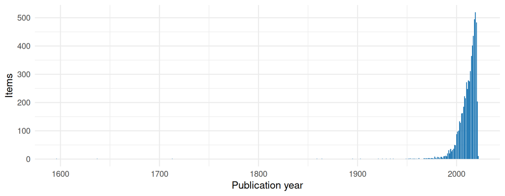

### Types of items

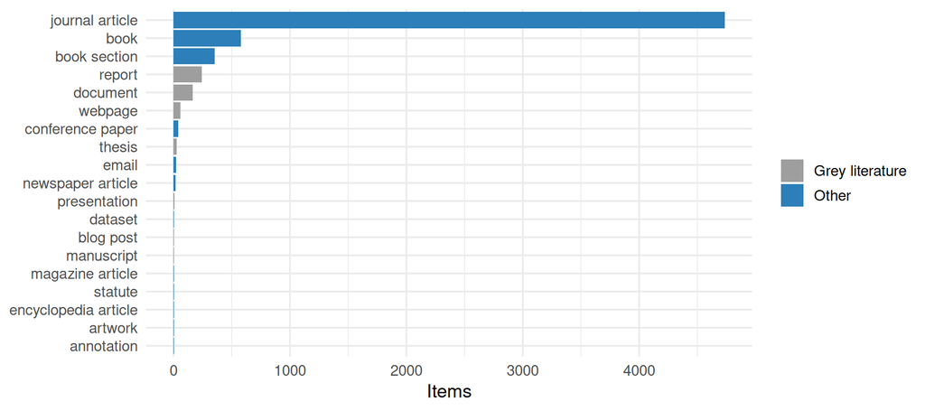

### Open access

Open access status of the publications found in OpenAlex. *Gold* and *diamond*: open in an open access journal; *hybrid*: open in a subscription journal; *green*: an open copy is in a repository; *bronze*: free to read on the publisher’s site; *closed*: not openly available.

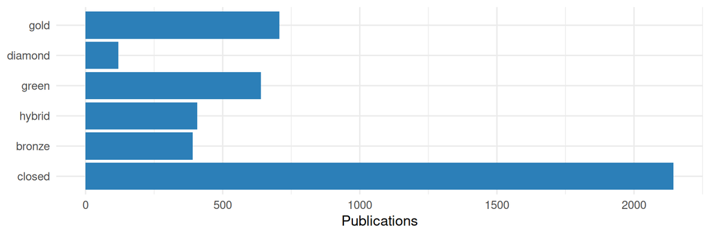

### Most frequent journals

| Journal | Items |
| --- | --- |
| Science | 112 |
| Biological Conservation | 110 |
| Marine Policy | 109 |
| Conservation Biology | 81 |
| Ecology and Society | 81 |
| Proceedings of the National Academy of Sciences | 73 |
| Nature | 63 |
| Oryx | 61 |
| Fish and Fisheries | 58 |
| Forest Ecology and Management | 53 |

### Countries of the authors

Number of publications with at least one author from the country, for the publications found in OpenAlex.

| Country | Publications |
| --- | --- |
| United States | 1480 |
| United Kingdom | 791 |
| Canada | 588 |
| Australia | 530 |
| Brazil | 306 |
| Germany | 289 |
| Netherlands | 255 |
| France | 250 |
| Sweden | 241 |
| South Africa | 237 |
| Spain | 205 |
| Italy | 184 |
| Norway | 181 |
| China | 152 |
| Switzerland | 134 |

## How the checks work

**NoteDetails of the checks**

#### identifiers

##### DOI coverage (`met_id_doi`)

Number and share of items with a valid DOI, and items whose DOI field is filled but contains no valid DOI. DOIs are extracted with `openalexPro::extract_doi()` and lower cased.

##### ISBN coverage (`met_id_isbn`)

Number and share of items with an ISBN, overall and for the item types which should have one (`book`, `bookSection`).

##### ISSN coverage (`met_id_issn`)

Number and share of items with an ISSN, overall and for the item types which should have one (`journalArticle`, `magazineArticle`).

##### ISSN not in the standard form (`met_id_issn_form`)

Items whose ISSN field is not in the standard form: each ISSN as `1234-567X` (with hyphen, capital X), several separated by “,”. The ISSNs are checked with their check digit. If all are valid, the standard form is proposed; otherwise the item is listed with the ISSNs which are not valid.

##### DOIs in the wrong field (`met_id_doi_misplaced`)

Items with an empty DOI field but a DOI in the `Url` or `Extra` field. These DOIs are not used for the OpenAlex lookup and should be moved to the DOI field.

##### DOIs in the wrong form (`met_id_doi_form`)

Items whose DOI field contains a valid DOI, but not as a bare DOI: as a link (`https://doi.org/10.…`), with a prefix (`doi:`, `DOI`), URL-encoded (`%5B` for `[`) or with spaces or other characters around it. Citation styles add the link themselves, so a link in the DOI field appears twice in a bibliography. The bare DOI is the one recognised by `openalexPro::extract_doi()`, keeping its upper and lower case.

##### DOIs which do not exist (`met_id_doi_exists`)

Items whose DOI field contains a DOI in the right form which does not exist at doi.org: usually a typo, a shortened DOI, or a DOI with extra characters at the end (`.`, `;`, a link to supplementary material). Only DOIs which are not found in OpenAlex are checked at doi.org. Where the DOI without the extra characters at the end exists, it is given as suggestion.

##### Items without identifier (`met_id_none`)

Items with none of DOI, ISBN, ISSN or Url. These items can neither be checked against OpenAlex nor easily be retrieved by readers.

##### DOIs found in OpenAlex for items without a DOI (`met_id_candidates`)

For items without a DOI, OpenAlex was searched by title, and by the PubMed ID (line `PMID: …` in Extra), and Crossref by ISBN and title (see [get_doi_candidates()]).

#### metadata

##### Filled fields per item type (`met_meta_fields`)

Percentage of items with a filled field, per item type, for the main fields: Title, Author, Publication Year, Publication Title, Publisher, DOI, ISBN, ISSN, Url, Abstract Note and Language. Not every field is expected for every item type, e.g. reports have no Publication Title.

##### Problematic publication years (`met_meta_year`)

Items whose date is missing (`missing`), from whose date Zotero could not derive a year (`unparseable`), or whose year lies in the future (`future`).

##### Duplicate items (`met_meta_duplicates`)

Items which are in the group more than once, identified by the same DOI, or by the same normalised title (lower case, letters and digits only), publication year and first word of the first author.

##### Language not given as a standard code (`met_meta_language`)

Items whose language is not given as a standard language code, i.e. a two-letter ISO 639-1 code, optionally with a region (`en`, `en-US`), but e.g. as a name (`English`), a three-letter code (`eng`) or in a different spelling (`EN`, `en_us`). Citation styles and other tools only recognise the codes. Where the value is recognised, the standard code is proposed, based on the ISO 639-2 list (R package ISOcodes): codes, three-letter codes and the English names of the languages. Other values, e.g. names in the language itself, several languages or other text, are listed without a proposal.

#### openalex_check

##### Zotero DOIs found in OpenAlex (`met_check_found`)

Valid Zotero DOIs which were / were not found in OpenAlex. A DOI which is not found is either not indexed by OpenAlex or wrong (see `met_id_doi_exists` for DOIs which do not exist). DOIs of works which OpenAlex has under another DOI (e.g. the old and the new DOI of an article) count as found.

##### Retracted works (`met_check_retracted`)

Works flagged as retracted by OpenAlex, with the key of the Zotero item(s) with the same DOI.

##### Wrong DOIs (`met_check_mismatch`)

Items whose DOI points in OpenAlex to a work with a different title or year, which usually means that the wrong DOI is attached to the item. An item is flagged when the title similarity (normalised Levenshtein distance) is below 0.8 or the years differ by more than one. Items with the line `DOI checked: correct` in Extra (someone checked that the DOI is right, e.g. a book chapter with the DOI of the book, or a wrong year in OpenAlex) are not listed.

##### Item type agreement (`met_check_type`)

Zotero item type compared with the OpenAlex work type for items with the same DOI.

##### Missing dates found in OpenAlex (`met_check_date`)

Items without a date whose DOI was found in OpenAlex: the publication date in OpenAlex is proposed. OpenAlex gives 1 January when only the year is known, so such dates are proposed as the year only. Items whose DOI points to a different publication are left out.

##### Empty fields found in OpenAlex (`met_check_fill`)

Journal articles with an empty journal, volume, issue or pages field whose DOI was found in OpenAlex with these details: the values in OpenAlex are proposed. The journal is only taken if the publication is in a journal in OpenAlex (not e.g. a repository). Page ranges which end before they start (e.g. `1260-2`, shortened or wrong) are not proposed. Items whose DOI points to a different publication are left out.

##### Language differs from OpenAlex (`met_check_language`)

Items whose language in Zotero differs from the language of their DOI in OpenAlex. Only the language is compared, not the region (`en-US` and `en` are the same), and only for items whose language is given as a language code (see “Language not given as a language code”). Items without a language are listed under “No language”.

##### OpenAlex ID in the Extra field (`met_check_openalex_id`)

Items whose DOI was found in OpenAlex, compared with the OpenAlex ID noted in their Extra field (a line `OpenAlex: W…`). Items without such a line can get it, which links them to OpenAlex for later checks. Items with a different ID are listed for checking: OpenAlex merges records, and the ID of a merged record redirects to the new one. Items whose DOI points to a different publication are left out.

##### OpenAlex ID in the Extra field not valid (`met_check_extra_id`)

Checks the lines `OpenAlex: …` in the Extra field (looked up by [get_extra_ids()]). A line is not valid if - it is not an OpenAlex work ID (`W` and digits), - the item has several lines with different IDs, - the ID is not in OpenAlex (wrong, or merged into another record), or - the work is a different publication: its DOI is not the DOI of the item, or, for items without DOI, its title is not similar (similarity below 0.8, see [title_similarity()]).

#### profile

##### Publication years (`met_prof_year`)

Number of items per publication year, with cumulative counts. Items without a year are counted as `NA`.

##### Open access status (`met_prof_oa`)

OpenAlex open access status (gold, diamond, green, hybrid, bronze, closed) of the works, overall and per publication year.

##### Top journals (`met_prof_journals`)

The 50 most frequent journals, from the Publication Title in Zotero and the source of the primary location in OpenAlex. Ties at rank 50 are included.

##### Author countries (`met_prof_countries`)

Number of works with at least one author affiliated with an institution in a country, per country (ISO 3166-1 alpha-2 codes from OpenAlex).

##### Item types and grey literature (`met_prof_types`)

Number of items per item type (Zotero) or work type (OpenAlex), and the share of grey literature, i.e. reports, theses, dissertations, web pages, documents, presentations, manuscripts, blog posts and preprints.

##### Languages (`met_prof_language`)

Languages as entered, and normalised to two letter codes (lower case, region removed, English spellings mapped to `en`). Inconsistent codes in the language as entered are a quality issue in themselves.

#### maintenance

##### Group activity (`met_maint_activity`)

Items added per month, and items added / modified in the 30 days before the metrics were calculated.

##### Items without tags (`met_maint_tags`)

Items without manual tags. Automatic tags, e.g. keywords imported from the publisher, are ignored.

IPBES Literature Report 0.7.0 · [source code on GitHub](https://github.com/IPBES-Data/IPBES.LiteratureReport) (© IPBES.LiteratureReport authors, [MIT licence](https://opensource.org/license/mit)) · reports and data on this website: [CC0 1.0](https://creativecommons.org/publicdomain/zero/1.0/) (no rights reserved)